# School diversity hearing

Nick Solomon and James Subudhi

April 30, 2019

# 1 City Overview

This section contains facts about all schools and students in New York City that were included in the 2017 committee report. All data is for the 2017-18 school year.

## 1.1 Race and Ethnicity

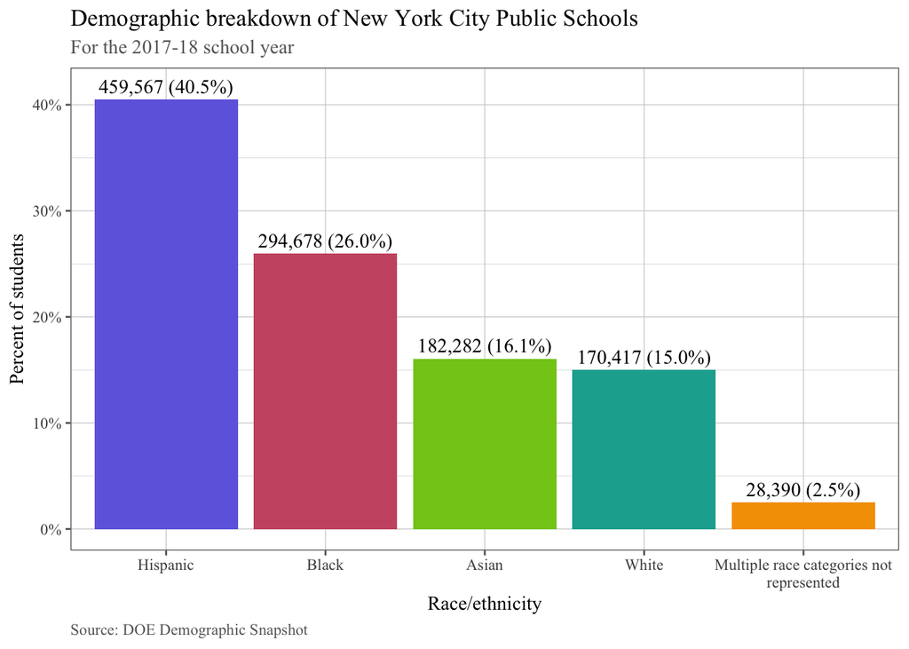

- 74.6% of black and Hispanic students attend a school that is less than 10% white students.
- 34.3% of white students attend a school with more than 50% white students

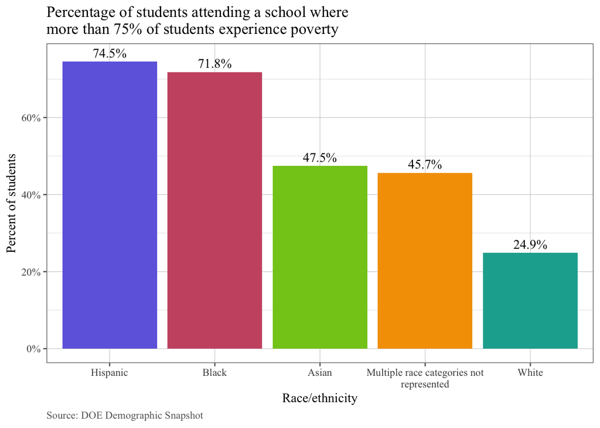

## 1.2 Poverty

- Citywide, 74.0% of students experience poverty. The citywide Economic Need Index is 70.7%.

## 1.3 ELL Students

- 25.2% of schools have a population of more than 20% ELL students
- 47.4% of schools have a population of less than 10% ELL students

## 1.4 Students With Disabilities

- 19.7% of students in New York City are students with disabilities.
- 6.06% of schools have a population that is less than 10% students with disabilities.

## 1.5 Students in temporary housing

- 29.2% of schools have a population of more than 15% of students in temporary housing.
- 4.63% of schools do not have any students in temporary housing.

# 2 Specialized High School Diversity

Specialized high schools have been an important part of the conversation around school diversity and integration in New York City. The graphic below shows the racial demographics of 8 of the 9 specialized high schools. LaGuardia High School is not show here as it has auditions based admissions. Clearly, severe discrepancies exist for those given access to the highest level of academic achievement New York City has to offer.

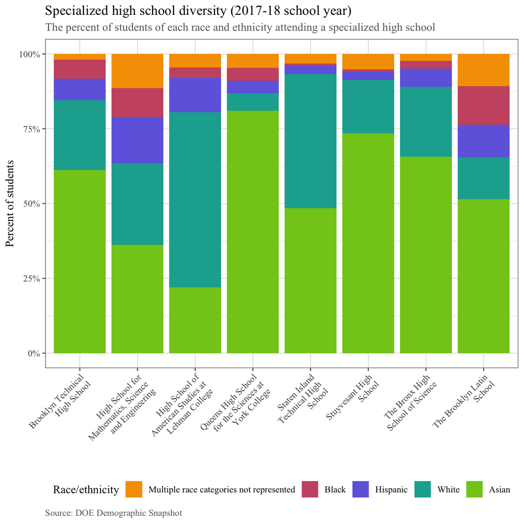

## 2.1 Poverty in Specialized High Schools

| School | Percent of Students Experiencing Poverty | Economic Need Index |
| --- | --- | --- |
| Stuyvesant High School | 44.3% | 41.8% |
| High School for Mathematics, Science and Engineering | 42.6% | 41.5% |
| The Bronx High School of Science | 44.2% | 39.5% |
| High School of American Studies at Lehman College | 20.3% | 24.1% |
| Brooklyn Technical High School | 60.8% | 52.0% |
| The Brooklyn Latin School | 61.7% | 52.7% |
| Queens High School for the Sciences at York College | 60.5% | 47.1% |
| Staten Island Technical High School | 40.8% | 35.1% |